# Preparing Senior Exit Data for analysis

Ri’ann Yates-Miller & Keidward Pichardo

# 1 Loading Necessary Packages and Environment

```r
knitr::opts_chunk$set(echo = TRUE,message=FALSE,warning=FALSE)

#package intialization
rm(list = ls()) # clear global environment
graphics.off() # close all graphics
if(require(pacman)==FALSE) install.packages("pacman")
pacman::p_load(DataExplorer,tidyverse,readxl,zoo,stargazer,kableExtra,skimr,plotly,ggpubr,vtable,tm)
```

# 2 Audience and Purpose

The purpose of this project is to take survey data and analyze it in order to provide recommendations on the effects of number of internships on salary. This will be done through the use of a regressive model to see which variables have are the biggest predictors of salary. Specifically, the effect of internships on salary. The identified audience for this analysis is the Associate Vice President for Development and External Relations.

## 2.1 Business Value Proposition

[figure not shown]

# 3 Data Sources

The data provided is a compilation of senior exit surveys from Miami University, Oxford and a table of census regions by state from github.

## 3.1 Read in the data

```r
data=readRDS(file = "FSB_BI_Survey_2019_2021.rds")
```

```r
geo = read_csv('https://raw.githubusercontent.com/cphalpert/census-regions/master/us%20census%20bureau%20regions%20and%20divisions.csv')
```

# 4 Data Descriptions and Exploratory Data Analysis

```r
introduce(data) # Provides quick descriptions of the data
```

| rows | columns | discrete_columns | continuous_columns | all_missing_columns | total_missing_values | complete_rows | total_observations | memory_usage |
| --- | --- | --- | --- | --- | --- | --- | --- | --- |
| 3235 | 42 | 24 | 18 | 0 | 27236 | 0 | 135870 | 1412920 |

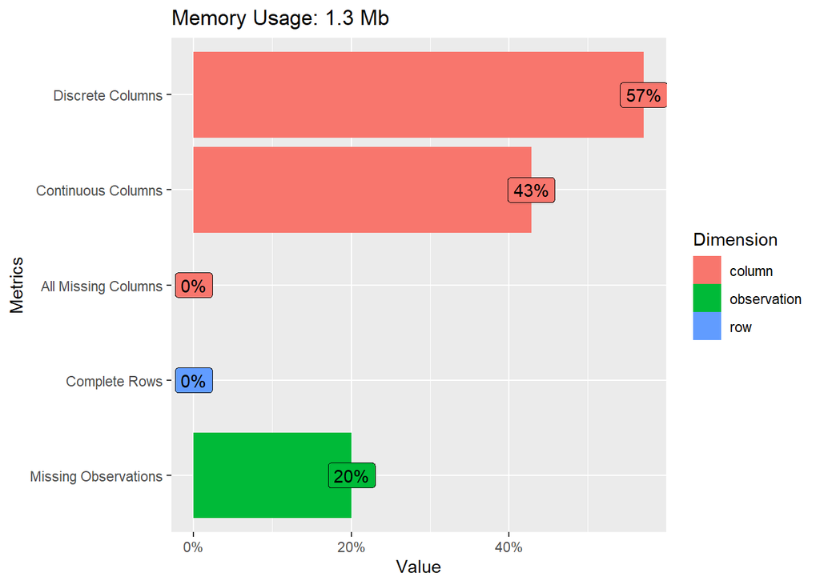

```r
plot_intro(data) # checking percent of missing observations for the whole data set
```

20% of the data has missing observations, we must pay attention to variables with a percentage of missing values higehr than 30% and cosider imputing or dropping these variables.

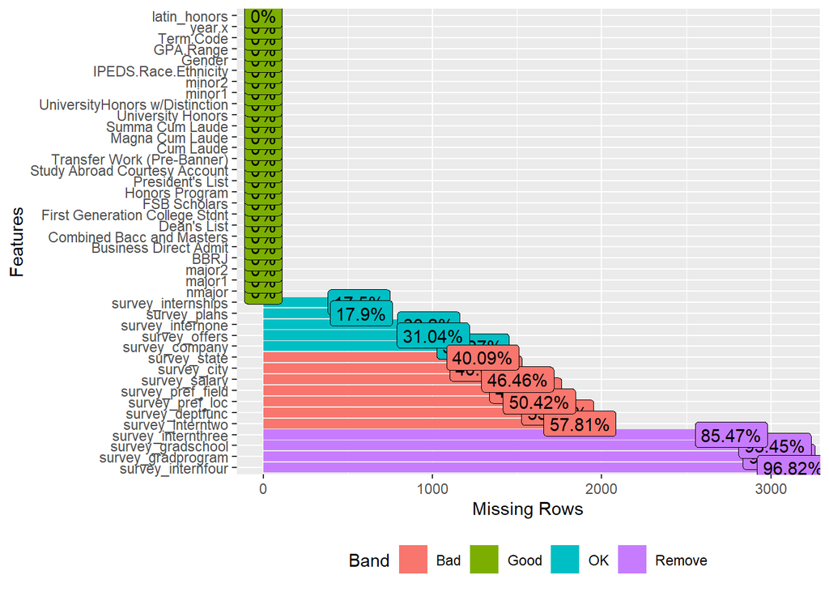

```r
plot_missing(data) #creates a graph of the percent missing for each variable
```

We must consider which of the variables with a percentage of missing observations above 50% are crucial to our analysis. To analyze the effects of internship on salary we must first ensure our response variable, survey_salary is ready for the analysis.

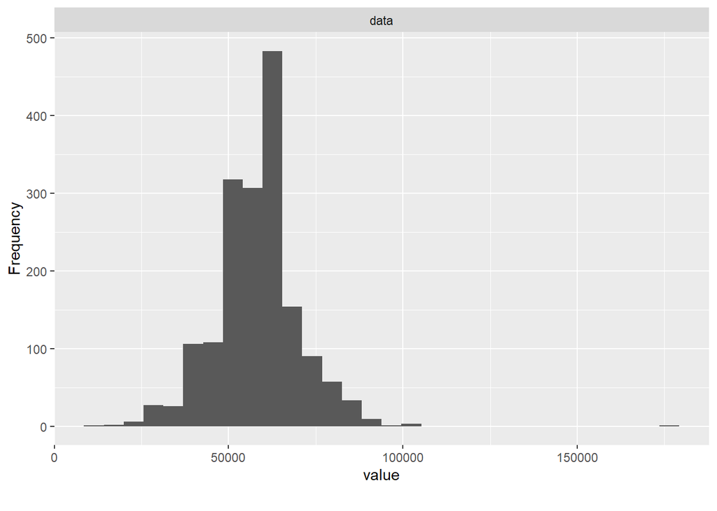

```r
plot_histogram(data$survey_salary) #shows the distribution of salary in order for us to see how to best impute the missing values
```

The data is slightly skewed to the right due to some extreme outliers. In order to handle the missing observations we will impute the mean salary for each major1 category.

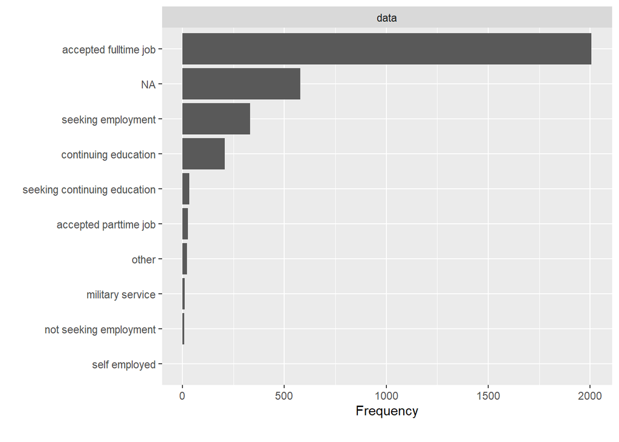

```r
plot_bar(data$survey_plans) # shows the distribution of responses for the variable survey_plans in order to assess what we need to control for in salary
```

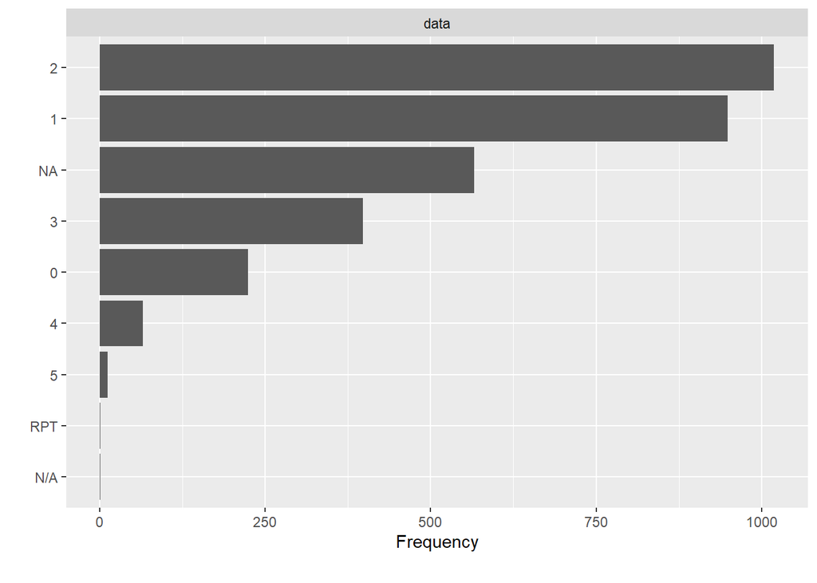

```r
plot_bar(data$survey_internships) #shows the distribution of responses for the variable survey_internships
```

Because survey_internships contains information on the number of internships the individual participated in, there is no need for any of the survey_intern variables that individually specify the number of internships each individual has, therefor we will drop all 4 of these variables.

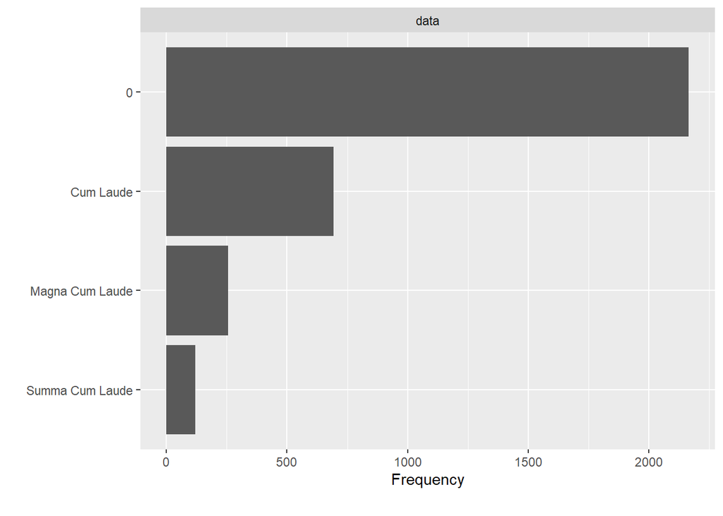

```r
plot_bar(data$latin_honors) # checking the observations in this variable
```

Because Latin honors holds the information for those graduated with Magna, Summa or just Cum Laude, we will drop the individual variables Magna, Summa and Cum Laude and use the variable latin_honors along with GPA.Range to control for academic achievements.

# 5 Variables we want to use

As previously mentioned, our two response variables are survey_salary and survey_plans due to the scope of our question. Additionally, we will keep the following variables: year.x, to control for changes in time GPA.Range and latin_honors to control for varying levels of academic success `Combined Bacc and Masters`, major1 and major2 to control for the differences in profession and quantity of majors/ masters Gender and IPEDS.Race.Ethnicity to control for pay differences by race, ethnicity or gender survey_state to control for location rather than survey_city, this will be dropped

the remaining variables will be removed due to their irrelevance to our analysis

## 5.1 subsetting data

```r
data = data |> # minimizing the data to the variables we will keep in the analysis
  dplyr::select(year.x, GPA.Range, major1, major2, survey_plans, survey_internships, survey_salary, Gender, IPEDS.Race.Ethnicity, latin_honors, `Combined Bacc and Masters`, survey_state)
```

## 5.2 changing data types

```r
#making all the categorical variables in our analysis factors for the purpose of constructing a regressive model
data$year.x = as.factor(data$year.x)
data$GPA.Range = as.factor(data$GPA.Range)
data$survey_plans = as.factor(data$survey_plans)
data$Gender = as.factor(data$Gender)
data$IPEDS.Race.Ethnicity = as.factor(data$IPEDS.Race.Ethnicity)
data$`Combined Bacc and Masters` =
  as.factor(data$`Combined Bacc and Masters`)

## if the variables aren't encoded here they will be encoded later in the analysis
```

# 6 Data Preprocessing

To effectively predict salary based on number of internships using regression. We will begin by cleaning up the survey_state variables so that all the state names are consistent. we will then use the imported data ‘geo’ which defines regions based on census data, to group the states into regions and reduce the levels in our analysis. We will then clean the variables major1 and major2 by ensuring all majors are relevant and correctly spelled. Additionally entrepreneurship will be switched from major 1 to 2. Finally, we will assess any missing observations that may affect our data.

## 6.1 Location Cleaning

```r
#the survey_state variables is of type character, need to convert to factor to check levels and model
data$survey_state = as.factor(data$survey_state)
#check the levels
levels(data$survey_state)
```

```
##   [1] "AR"                           "AZ"
##   [3] "Belize"                       "CA"
##   [5] "California"                   "Canada"
##   [7] "China"                        "CO"
##   [9] "Colorado"                     "Colorado/ United States"
##  [11] "Connecticut"                  "CT"
##  [13] "D.C."                         "DC"
##  [15] "Delaware"                     "District of Columbia"
##  [17] "FL"                           "Florida"
##  [19] "Fujian Province"              "GA"
##  [21] "Georgia"                      "Georgia, USA"
##  [23] "IA"                           "iL"
##  [25] "Il"                           "IL"
##  [27] "IL, United States"            "IL, US"
##  [29] "IL, USA"                      "IL/ USA"
```

[output cut: 48 more lines]

this variable has too many levels and differences in entries for the same intended location. The variable is supposed to only hold states as responses, however there are locations listed outside of the united states. On the assumption that our client does not know enough about locations outside of the US and its effect on salary, we will classify all observations that are not states as NA.

```r
#cleaning the observations
# Convert state names to uppercase for consistency
data$survey_state <- tolower(data$survey_state)

#remove abbreviations
data$survey_state <- gsub("[^a-zA-Z]", "", data$survey_state)

#convert to numerical representations
data$survey_state <- match(data$survey_state, tolower(state.abb))

data$survey_state <- state.name[(data$survey_state)]
print(unique(data$survey_state))
```

```
##  [1] NA               "Ohio"           "New York"       "Georgia"
##  [5] "Illinois"       "California"     "Kansas"         "Minnesota"
##  [9] "North Carolina" "Kentucky"       "Texas"          "Nevada"
## [13] "Indiana"        "Wisconsin"      "Massachusetts"  "Colorado"
## [17] "Washington"     "New Jersey"     "Utah"           "Missouri"
## [21] "Michigan"       "Iowa"           "Pennsylvania"   "Virginia"
## [25] "Rhode Island"   "Arizona"        "Maine"          "Connecticut"
## [29] "Maryland"       "Tennessee"      "Arkansas"       "Florida"
## [33] "Mississippi"    "Louisiana"      "South Carolina" "New Hampshire"
## [37] "Nebraska"
```

```r
data$State = data$survey_state # changing the name so it matches the geo data for a merge
```

Because of the high volume of NA values in the states, we don’t want to delete them from the data set. Therefore, we will simply encode this data as missing.

```r
# making the unknown values a separate factor
data$State = fct_explicit_na(data$State, 'Unknown')
```

Merging the Region table (geo) and the states, while maintaining the unknown values

```r
## Needed for the following steps to maintain the unknown values with the merge
data$State = as.character(data$State)
```

To maintain the null values we subset the data frame, so this data would not be loss in the merge. We also made sure that the columns name and quantity matched between the two data sets.

```r
# subsetting for Unknown
Loc_unknown = subset(data, State == 'Unknown')

# Dropping survey state
Loc_unknown = subset(Loc_unknown, select = -c(survey_state))

# Renaming the State Column
Loc_unknown = Loc_unknown %>%
  rename('Region' = 'State')
```

Merging the Data

```r
# preparing the data df for the merge
data = subset(data, State != 'Unknown')
```

```r
# merging geo table and data table by State
data = merge(data, geo, by = "State")
```

```r
data = data |> # minimizing the data to the variables we will keep in the analysis
  subset(select = -c(survey_state, Division, `State Code`, State))
```

```r
## Combining the datasets
data = rbind(data, Loc_unknown)
```

## 6.2 Major1 Cleaning

```r
unique(data$major1)
```

```
##  [1] Finance                        Marketing
##  [3] Supply Chain & Operations Mgmt Accountancy
##  [5] Information Systems            Human Capital Mgmt& Leadership
##  [7] Management and Leadership      Business Economics
##  [9] Business Analytics             Entrepreneurship
## [11] Management and Organizations   Interdisciplinary Bus Managemt
## [13] General Business
## 13 Levels: Accountancy Business Analytics ... Supply Chain & Operations Mgmt
```

```r
library(dplyr)

# Apply the correction selectively
data = data %>%
  mutate(major1 = ifelse(major1 %in% c("Management and Leadership", "Management and Organizations", "Human Capital Mgmt& Leadership"), "Human Capital Mgmt & Leadership", as.character(major1)))

# Verify the results
unique(data$major1)
```

```
##  [1] "Finance"                         "Marketing"
##  [3] "Supply Chain & Operations Mgmt"  "Accountancy"
##  [5] "Information Systems"             "Human Capital Mgmt & Leadership"
##  [7] "Business Economics"              "Business Analytics"
##  [9] "Entrepreneurship"                "Interdisciplinary Bus Managemt"
## [11] "General Business"
```

### 6.2.1 What is Interdisciplinary Business Management ?

This variable only holds 13 observations and no salary data. This Will skew our analysis and provides no relevant information. the observations will be dropped

```r
data = data[data$major1 != "Interdisciplinary Bus Managemt", ]

# Verify the results
unique(data$major1)
```

```
##  [1] "Finance"                         "Marketing"
##  [3] "Supply Chain & Operations Mgmt"  "Accountancy"
##  [5] "Information Systems"             "Human Capital Mgmt & Leadership"
##  [7] "Business Economics"              "Business Analytics"
##  [9] "Entrepreneurship"                "General Business"
```

### 6.2.2 Entrepreneurship can only be a co-major or minor.

these observations should be moved to major 2 as for those who do not have a major 2, entrepreneurship cannot be major 1.

```r
data$major1 <- as.character(data$major1)
data$major2 <- as.character(data$major2)
data[data$major1 == "Entrepreneurship", c("major1", "major2")] <- data[data$major1 == "Entrepreneurship", c("major2", "major1")]
```

```r
## making major1 a factor again, we further encode major2 later
data$major1 = as.factor(data$major1)
```

```r
# Verify the results
unique(data$major1)
```

```
## [1] Finance                         Marketing
## [3] Supply Chain & Operations Mgmt  Accountancy
## [5] Information Systems             Human Capital Mgmt & Leadership
## [7] Business Economics              Business Analytics
## [9] General Business
## 9 Levels: Accountancy Business Analytics Business Economics ... Supply Chain & Operations Mgmt
```

### 6.2.3 What’s general business ?

This observation contains only one row and almost all of the data within this row is NA, these observations will also be removed

```r
data = data[data$major1 != "General Business", ]
# Verify the results
unique(data$major1)
```

```
## [1] Finance                         Marketing
## [3] Supply Chain & Operations Mgmt  Accountancy
## [5] Information Systems             Human Capital Mgmt & Leadership
## [7] Business Economics              Business Analytics
## 9 Levels: Accountancy Business Analytics Business Economics ... Supply Chain & Operations Mgmt
```

## 6.3 imputing survey_salary

```r
  data=data |>
  dplyr::group_by(major1) |># grouping by major to obtain mean salary per major
  mutate(survey_salary=replace(survey_salary,is.na(survey_salary), mean(survey_salary,na.rm=T))) #filling all NA observations with the mean salalry for that respective major.

#verifying results
sum(is.na(data$survey_salary))
```

```
## [1] 0
```

## 6.4 Internship Condensing

In order to better interpret number of internships we will re-construct the variable to better match the scope of the question. Our client is interested in knowing whether 0, 1 or more than one internship leads to a higher salary. We will group the observations within the variable survey_internships so that for all internship counts greater than 1 it shows “MoreThanOne”

```r
data$survey_internships <- fct_collapse(data$survey_internships,
  None = "0",
  One = "1",
  MoreThanOne = c("2", "3", "4", "5")
)
```

```r
data$survey_internships = as.factor(data$survey_internships) # transforming into a factor for the purpose of our regressive model
```

## 6.5 Making Latin Honors Binary

Why we want to make this binary for better interpretation. If you have a Latin honors, regardless of its level to simplify the levels within the variable and its interpretation for our analysis. We want to be able to generalize the conclusion and tell the client wether Latin honors in general is significant enough to control for.

```r
data$latin_honors = ifelse(
  data$latin_honors != "0",
  1,
  0)
```

```r
data$latin_honors = as.factor(data$latin_honors)
```

## 6.6 Making Major2 Binary

Similar to Latin Honors, we want to control for if having a second major affects salary. To do this and simplify our analysis, we want to make this a Binary variable for the purpose of assessing salary differences by quantity of majors not secondary category.

```r
data$major2 = ifelse(
  data$major2 != "none",
  1,
  0)
```

```r
data$major2 = as.factor(data$major2) # transforming into a factor for the purpose of our regressive model
```

## 6.7 Drop remaining NAs

In order to ensure that the variables survey_internships and survey_plans are clean and accurate for our analysis in predicting salary we must drop the remaining NA values. these variables are not easily amputated, so rather than risking the accuracy of our analysis, we will drop these values from the variable.

```r
data = data |> na.omit()
data
```

| year.x | GPA.Range | major1 | major2 | survey_plans | survey_internships | survey_salary | Gender | IPEDS.Race.Ethnicity | latin_honors | Combined Bacc and Masters | Region |
| --- | --- | --- | --- | --- | --- | --- | --- | --- | --- | --- | --- |
| 2019 | 3.50 - 4.00 | Finance | 0 | accepted fulltime job | MoreThanOne | 61083.66 | Male | White | 1 | 0 | West |
| 2019 | 3.00 - 3.49 | Finance | 0 | accepted fulltime job | One | 54000.00 | Male | White | 0 | 0 | West |
| 2021 | 3.00 - 3.49 | Marketing | 0 | accepted parttime job | None | 30000.00 | Female | Multi Racial | 0 | 0 | West |
| 2020 | 3.50 - 4.00 | Supply Chain & Operations Mgmt | 0 | accepted fulltime job | MoreThanOne | 53000.00 | Male | White | 1 | 0 | West |
| 2019 | 2.50 - 2.99 | Marketing | 0 | accepted fulltime job | One | 52222.73 | Female | White | 0 | 0 | West |
| 2020 | 3.00 - 3.49 | Marketing | 0 | accepted fulltime job | MoreThanOne | 58000.00 | Female | White | 0 | 0 | South |
| 2021 | 3.50 - 4.00 | Marketing | 0 | accepted fulltime job | MoreThanOne | 58000.00 | Female | Multi Racial | 1 | 0 | South |
| 2020 | 3.50 - 4.00 | Marketing | 0 | accepted fulltime job | MoreThanOne | 52222.73 | Male | White | 1 | 0 | South |
| 2021 | 3.50 - 4.00 | Accountancy | 0 | accepted fulltime job | One | 73000.00 | Male | White | 1 | 1 | West |
| 2020 | 3.50 - 4.00 | Finance | 0 | accepted fulltime job | One | 70000.00 | Female | White | 1 | 0 | West |

[output cut: 2451 more lines]

# 7 Conclusion

Now that our data is clean and ready for analysis, we will construct a regressive model to predict salary.